# Praca domowa 2

Damian Skowroński

30/11/2021

## Wprowadzenie

Za zadanie mieliśmy przygotować wizualizację, która jest poprawą gotowej wizujalizacji dostępnej w internecie. Ja zająłem się wizualizacją, która pochodzi ze strony https://www.economist.com/graphic-detail/2021/10/12/the-imf-warns-that-the-global-economic-recovery-will-be-grossly-uneven i wygląda następująco:

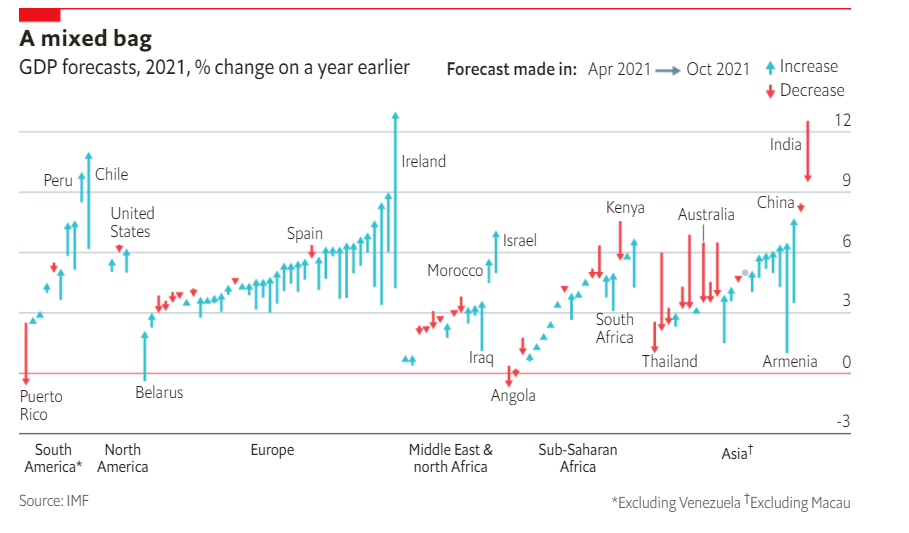

Moim zdaniem jest tu kilka problemów, mianowicie:

1. Problem z dokładnym odczytaniem, gdzie zaczynają się i kończą strzałki.
2. Podpisanie tylko niektórych strzałek, z nieokreślonym powodem.
3. Niekiedy niepewność w odczytaniu, który podpis należy do której strzałki.
4. Niekoniecznie celna przynależność państw do kontynentów (Puerto Rico w Południowej Ameryce, Australia w Azji).

## Poprawiona wizualizacja

Kod potrzebny do wykonania wizualizacji jest na końcu raportu. W wizualizacji połączyłem ze sobą Amerykę Płudniową i Północną, a także nie wziąłem pod uwagę Oceanii, żeby rozmiar był mniejszy, a także dlatego że w Oceanii jest dużo mniej państw i tu nie potrafie przeskalować tego wykresu, żeby był mniejszy.

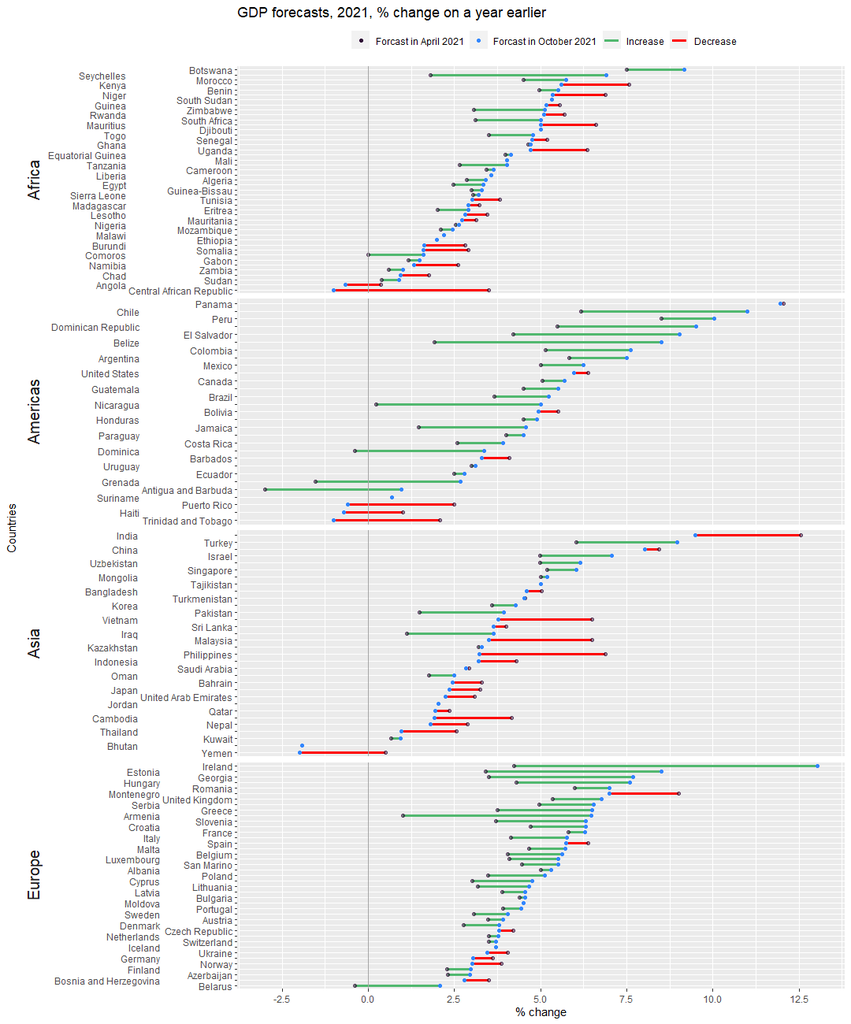

W celu uniknięcia stosowania wcześniejszych ułatwień zrobiłem na inny wykres, który ma już dokładnie ustawione państwa względem kontynentów i zawiera wszystkie te, z których były dostępne dane. W tym rozwiązaniu mogłem przedstawić oddzielnie kontynenty, ponieważ potrafiłem ustawić wielkość każdego z wykresów. (Wykres nie jest dokończony, to znaczy nie ma legendy i tytułów.)

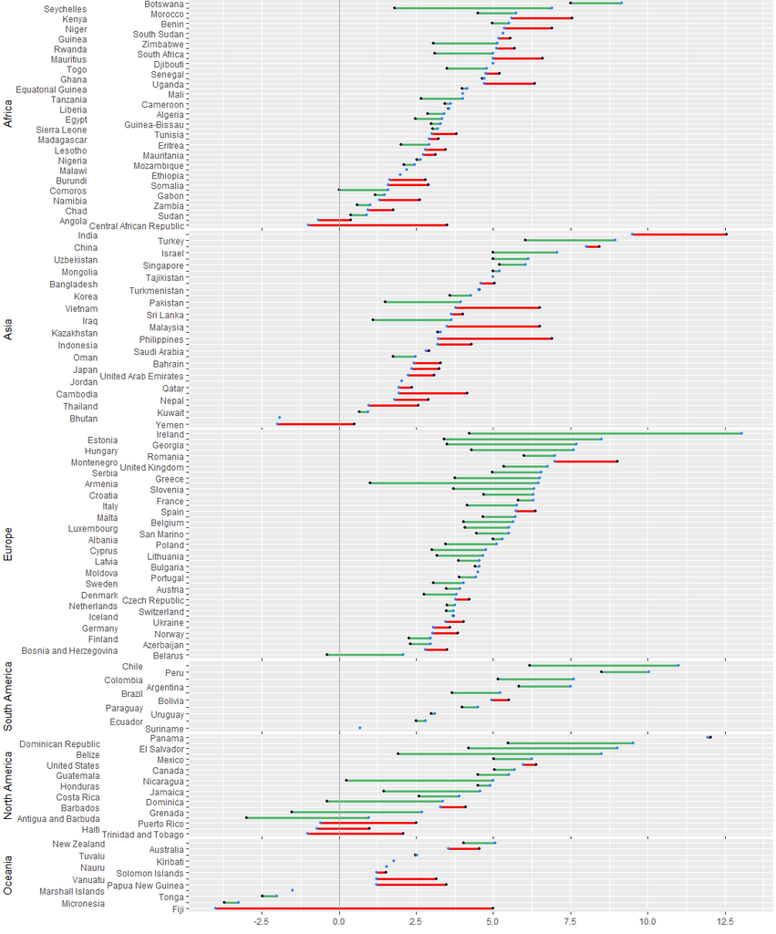

## Podsumowanie

Moim zdaniem udało mi się naprawić wcześniej wymienione problemy. Wydaje mi się natomiast, że pojawił się inny problem. Mianowicie: moja wizualizacja jest większa i ma dużo więcej podpisów, przez co może być trudniejsza do odczytania.

## Kod

Wczytanie ramek danych i bibliotek:

```r
library(readr)
library(ggplot2)
library(dplyr)
library(cowplot)

kraje <- read_csv("krajeKontyn.csv")  #Countries with continents

df_oct <- read_csv("WEO_Dataoct.xls.csv", #October dataframe
                           col_types = cols(`2021` = col_double(),
                                            `Subject Descriptor` = col_skip(),
                                            Units = col_skip(), Scale = col_skip(),
                                            `Country/Series-specific Notes` = col_skip(),
                                            `Estimates Start After` = col_skip(),
                                            `2019` = col_skip(),
                                            `2020` = col_skip())) %>%
  mutate("oct" = `2021`) %>%
  select(-`2021`)



df_apr <- read_csv("WEO_Dataapr.xls.csv", #April dataframe
                            col_types = cols(`2021` = col_double(),
                                             `Subject Descriptor` = col_skip(),
                                             Units = col_skip(), Scale = col_skip(),
                                             `Country/Series-specific Notes` = col_skip(),
                                             `Estimates Start After` = col_skip(),
                                             `2020` = col_skip())) %>%
  mutate("apr" = `2021`) %>%
  select(-`2021`)
```

Działanie na ramkach danych i stworzenie wykresu

```r
df <- left_join(df_apr,df_oct,by="Country") %>%
  left_join(kraje, by = "Country") %>%
  filter(!is.na(apr), !is.na(oct),!is.na(Continent),oct<15,apr>-3,Continent != "Oceania") %>%
  group_by(Continent) %>%
  mutate(Country = forcats::fct_reorder(Country,oct),colo = ifelse(oct>apr,"#51B86F","#FF0000"))


Plt1 <- df %>%
  ggplot() +
  geom_segment( aes(x=Country, xend=Country, y=apr, yend=oct,color = colo ),size = 1.1 ) +
  geom_point(aes(x=Country, y=apr,color="#2F0B36"), size=1.4,alpha =0.5) +
  geom_point( aes(x=Country, y=oct, color="#3387FF"), size=1.4 ) +
  geom_hline(yintercept = 0,color="#a6a6a6")+
  scale_x_discrete(guide = guide_axis(n.dodge = 2)) +
  scale_y_continuous(breaks=seq(-5,12.5,2.5)) +
  coord_flip() +
  facet_wrap(vars(Continent), scales = "free_y", nrow = 4, strip.position = "left") +
  # z jakiegoś powodu mam problem z zamienianiem się, kolorów między segmentami i punktami
  # ewentualnie jak kolory się zgadzają to nie zgadzają się z legendą...
  # w ostatecznym rozwiązaniu i tak legenda mi się ustawia w kolejności alfabetycznej względem hex kolorów
  scale_color_identity(name ="",
                       labels=c("Forcast in April 2021", "Forcast in October 2021","Increase","Decrease"),
                       guide = guide_legend(override.aes = list(
                         linetype = c("blank","blank", "solid", "solid"),
                        shape = c(16,16, NA, NA)))) +
  theme(strip.background = element_blank(),
        strip.placement = "outside",
        strip.text = element_text(size=15),
        axis.text.y = element_text(size = 9),
        legend.position = "top")+
  labs(title = "GDP forecasts, 2021, % change on a year earlier", x = "Countries", y = "% change")
```

Ostatecznie ramka wygląda tak:

| Country | apr | oct | Continent | colo |
| --- | --- | --- | --- | --- |
| Albania | 5.000 | 5.300 | Europe | #51B86F |
| Algeria | 2.864 | 3.410 | Africa | #51B86F |
| Angola | 0.373 | -0.655 | Africa | #FF0000 |
| Antigua and Barbuda | -2.987 | 0.965 | Americas | #51B86F |
| Argentina | 5.839 | 7.500 | Americas | #51B86F |

Dodatkowy kod potrzebny do drugiego wykresu:

```r
kraje2 <- read_csv("krajeKontyn2.csv")

df2 <- left_join(df_apr,df_oct,by="Country") %>%
  left_join(kraje2, by = "Country") %>%
  filter(!is.na(apr), !is.na(oct),!is.na(Continent))


df2_cont <- function(dataframe,name){
  #funkcja robi ramki danych do odpowiednich kontynentów
  dataframe %>%
    filter(Continent == name,oct<15,apr>-5) %>%
    mutate(Country = forcats::fct_reorder(Country,oct))
}


cont_plot <- function(dataframe,b=TRUE){
  #funkcja robi ploty dla wcześniejszych ramek kontynentów
  dataframe %>%
    ggplot() +
    geom_segment( aes(x=Country, xend=Country, y=apr, yend=oct),size = 1.1, color = ifelse(dataframe$oct>dataframe$apr,"#51B86F","#FF0000")) +
    geom_point(aes(x=Country, y=apr), color="#2F0B36", size=1) +
    geom_point( aes(x=Country, y=oct,), color="#3387FF", size=1 ) +
    geom_hline(yintercept = 0,color="#a6a6a6")+
    coord_flip() +
    scale_x_discrete(guide = guide_axis(n.dodge = 2)) +
    scale_y_continuous(breaks=seq(-5,12.5,2.5), limits = c(-4,13.2)) +
    {if(b){ #zeby nie bylo x axis dla wszystkich kontynenow oprocz Oceanii na samym dole
      theme(axis.text.y = element_text(size = 9),
            axis.title.x=element_blank(),
            plot.margin = unit(c(0, 0, 0, 0), "cm"),
            axis.text.x = element_blank())
    }else{
      theme(axis.text.y = element_text(size = 9),
            axis.title.x=element_blank(),
            plot.margin = unit(c(0, 0.1, 0.3, 0.1), "cm"))
    }}
}


p_afr <- cont_plot(df2_cont(df2,"Africa")) +xlab("Africa")
p_asi <- cont_plot(df2_cont(df2,"Asia")) +xlab("Asia")
p_eur <- cont_plot(df2_cont(df2,"Europe")) +xlab("Europe")
p_sa <- cont_plot(df2_cont(df2,"South America")) +xlab("South America")
p_na <- cont_plot(df2_cont(df2,"North America")) +xlab("North America")
p_oce <- cont_plot(df2_cont(df2,"Oceania"),F) +xlab("Oceania")


Plt2 <- plot_grid(p_afr,p_asi,p_eur,p_sa,p_na, p_oce,
                 ncol=1, align='v', label_y = 1,rel_heights = c(2.2,1.9,2.2,0.7,1,0.9))
```